# Stone Sentinels

The Enigmatic Towers of the Sino-Tibetan Borderlands

Author

Ryan Lafferty

Published

March 4, 2026

“They rise out of the gorges like stone fingers pointing at the sky — hundreds of them, some over a thousand years old, and almost no one in the outside world knew they existed.”

— Frédérique Darragon, 2003 (Darragon 2003)

## Prologue: A Discovery Hidden in Plain Sight

In the autumn of 1998, French explorer Frédérique Darragon was trekking through the deep river valleys of western Sichuan Province, tracking snow leopards, when she encountered something that had eluded sustained Western scholarly attention for centuries: clusters of massive stone towers, some soaring above 50 meters, rising from villages and ridgelines across the Sino-Tibetan borderlands.

The towers were not unknown. Local Qiang (羌) and Gyalrong Tibetan communities had lived among them for generations. Chinese historians had referenced *diaolou* (碉楼, literally “watchtower buildings”) since at least the Tang Dynasty. But in the Western geographical imagination, these structures barely registered: overshadowed by the Silk Road, the Great Wall, and the monasteries of central Tibet.

**NoteMap Note**

The interactive map below places all seven documented site clusters on a terrain basemap. Use the **Fullscreen** button for a full-window view. Toggle between **Esri Shaded Relief** and **Label Overlay** to see terrain context and place names.

## Data & Setup

```python
import json
import sys
import os
import warnings
warnings.filterwarnings("ignore")

import pandas as pd
import matplotlib.pyplot as plt
import matplotlib.patches as mpatches
import folium
from folium.plugins import Fullscreen, MiniMap, MousePosition

sys.path.append("..")

# Load site data
with open("StoneTowerSites.json", encoding="utf-8") as f:
    sites = json.load(f)
sites_df = pd.DataFrame(sites)

# Check prettymaps availability
try:
    import prettymaps
    from importlib.metadata import version as _pkg_version
    HAS_PRETTYMAPS = True
    try:
        _pm_ver = _pkg_version("prettymaps")
    except Exception:
        _pm_ver = "unknown"
    print(f"prettymaps {_pm_ver} available")
except ImportError:
    HAS_PRETTYMAPS = False
    print("prettymaps not found — install with: pip install prettymaps")

print(f"\nLoaded {len(sites)} tower site clusters")
print(sites_df[["name", "ethnic_group", "tower_count"]].to_string(index=False))
```

```
prettymaps 1.4.2 available

Loaded 7 tower site clusters
                 name            ethnic_group                    tower_count
Danba / Suopo Cluster        Gyalrong Tibetan 13+ documented (Suopo cluster)
    Maerkang (Barkam)        Gyalrong Tibetan     Dozens; partially surveyed
      Jinchuan County        Gyalrong Tibetan     Dozens; partially surveyed
       Heishui County                   Qiang     Scores; partially surveyed
       Songpan County                   Qiang     Scattered; poorly surveyed
    Chamdo Prefecture Tibetan (mixed/unknown)  Few confirmed; access limited
     Yushu Prefecture Tibetan (mixed/unknown)  Tentative; survey data sparse
```

## The Landscape: Where the Towers Stand

### Physiographic Setting

The towers occupy one of the most tectonically and culturally complex corridors on Earth: the eastern escarpment of the Tibetan Plateau, where elevations plunge from above 4,000 m to below 1,500 m over horizontal distances of less than 100 km. The region is defined by three major river systems: the **Dadu River** (大渡河), the **Min River** (岷江), and the **Yalong River** (雅砻江), all of which have carved deep, fortifiable gorges through Mesozoic limestone and Paleozoic granite (Yin and Harrison 2000; Kirby et al. 2003).

This is not merely backdrop. The geology *enables* the towers: abundant tabular stone for dry-stack masonry, slopes that create natural defensible positions, and narrow valley floors that funnel movement along predictable routes, the same routes later formalized as the **Tea-Horse Road** (茶马古道) (Freeman and Ahmed 2015; Yang 2004).

### Primary Zone: Aba and Garzê Prefectures, Sichuan

**Danba County (丹巴县)** Coordinates: ~30.88°N, 101.89°E | Elevation: 1,800–3,200 m

The densest surviving concentration. The **Suopo Tower Cluster** (梭坡碉楼群), with 13 towers visible from a single vantage, is the most photographed and studied group. The nearby **Jiaju Tibetan Village** (甲居藏寨) preserves towers integrated into a living residential landscape. Danba towers exhibit the full range of cross-sectional geometries, from square to 13-pointed star plans.

*Sources*: Darragon (2003); Li and Chen (2009); World Monuments Fund (2006)

**Maerkang (马尔康) and Jinchuan (金川) Counties** Coordinates: ~31.90°N, 102.22°E / ~31.47°N, 102.01°E | Elevation: 2,600–3,400 m

Seat of the historical Gyalrong kingdoms. Towers here tend to be taller and more militaristic in design, reflecting centuries of inter-valley conflict and resistance to Qing imperial expansion. The Jinchuan campaigns of 1747–49 and 1771–76 are well-documented triggers for fortification (Theobald 2013).

**Heishui County (黑水县) and Songpan County (松潘县)** Coordinates: ~32.06°N, 102.99°E / ~32.65°N, 103.57°E | Elevation: 2,300–3,800 m

Predominantly Qiang-associated towers. The Qiang *diaolou* tradition tends toward square or rectangular plans, more frequently integrated into residential compounds as a single defensive wing of a larger house (Wang 2007).

### Secondary Zones

**Chamdo Prefecture (昌都), Tibet Autonomous Region** Coordinates: ~31.17°N, 97.17°E | Elevation: 3,200–4,000 m

The westernmost confirmed extension of the tower tradition. Structures here are fewer, more weathered, and less studied. Some researchers argue these represent an independent tradition; others see them as the western edge of a single cultural continuum (Aldenderfer and Zhang 2004).

**Yushu Tibetan Autonomous Prefecture (玉树), Qinghai Province** Coordinates: ~33.00°N, 97.02°E | Elevation: 3,600–4,200 m

Tentative. The devastating 2010 earthquake (Ms 6.9) destroyed much of Yushu’s built heritage, making retrospective identification challenging. Tower presence here is possible but not definitively confirmed (Liu et al. 2011).

## Site Distribution

```python
display_df = sites_df[[
    "name", "county", "ethnic_group", "tower_count", "plan_types", "status", "period"
]].copy()
display_df.columns = [
    "Site Cluster", "County", "Ethnic Group", "Tower Count", "Plan Types", "Protection Status", "Period"
]

display_df.style\
    .set_properties(**{"font-size": "0.87em"})\
    .set_table_styles([
        {"selector": "th", "props": [
            ("background-color", "#7c3d12"),
            ("color", "#faf8f4"),
            ("font-size", "0.85em"),
            ("padding", "6px 10px"),
        ]},
        {"selector": "td", "props": [("padding", "5px 10px")]},
        {"selector": "tr:nth-child(even)", "props": [("background-color", "#fef9ec")]},
    ])\
    .hide(axis="index")
```

Documented stone tower site clusters. Tower counts are estimates based on available surveys.

| Site Cluster | County | Ethnic Group | Tower Count | Plan Types | Protection Status | Period |
| --- | --- | --- | --- | --- | --- | --- |
| Danba / Suopo Cluster | Danba (丹巴县) | Gyalrong Tibetan | 13+ documented (Suopo cluster) | Square to 13-pointed star | WMF Watch 2006 / Provincial Protected | ~10th–18th c. |
| Maerkang (Barkam) | Maerkang (马尔康市) | Gyalrong Tibetan | Dozens; partially surveyed | Square, hexagonal | Provincial Protected (selected sites) | ~12th–18th c. |
| Jinchuan County | Jinchuan (金川县) | Gyalrong Tibetan | Dozens; partially surveyed | Square, star (6-pointed) | Provincial Protected (selected sites) | ~14th–18th c. |
| Heishui County | Heishui (黑水县) | Qiang | Scores; partially surveyed | Square, rectangular | Some Provincial Protected | ~8th–16th c. |
| Songpan County | Songpan (松潘县) | Qiang | Scattered; poorly surveyed | Square | Limited formal protection | ~8th–14th c. |
| Chamdo Prefecture | Chamdo (昌都市) | Tibetan (mixed/unknown) | Few confirmed; access limited | Square (inferred) | Limited formal protection | Unknown; possibly pre-10th c. |
| Yushu Prefecture | Yushu (玉树市) | Tibetan (mixed/unknown) | Tentative; survey data sparse | Unknown | Post-earthquake heritage survey ongoing | Unknown |

## The Regional Map: Where the Towers Stand

```python
# ---------------------------------------------------------------------------
# Ethnic group color palette
# ---------------------------------------------------------------------------
GROUP_COLORS = {
    "Gyalrong Tibetan": "#a16207",    # amber/gold
    "Qiang": "#be185d",               # rose
    "Tibetan (mixed/unknown)": "#6b7280",  # slate
}

def make_div_icon(color, size=20):
    """Circular DivIcon with drop shadow."""
    return folium.DivIcon(
        icon_size=(size, size),
        icon_anchor=(size // 2, size // 2),
        html=(
            f'<div style="'
            f'width:{size}px;height:{size}px;'
            f'border-radius:50%;'
            f'background:{color};'
            f'border:2.5px solid white;'
            f'box-shadow:0 1px 4px rgba(0,0,0,0.45);'
            f'"></div>'
        ),
    )

def make_popup(site):
    """Styled HTML popup card."""
    color = GROUP_COLORS.get(site["ethnic_group"], "#6b7280")
    return folium.Popup(
        folium.IFrame(
            html=(
                '<div style="font-family:\'Inter\',sans-serif;padding:4px;">'
                f'<h4 style="margin:0 0 6px;color:#7c3d12;font-size:1em;">{site["name"]}</h4>'
                '<table style="width:100%;font-size:0.82em;border-collapse:collapse;">'
                f'<tr><td style="color:#78716c;padding:2px 4px 2px 0;white-space:nowrap;">County</td>'
                f'<td style="padding:2px 0;">{site["county"]}</td></tr>'
                f'<tr><td style="color:#78716c;padding:2px 4px 2px 0;">Prefecture</td>'
                f'<td>{site["prefecture"]}</td></tr>'
                f'<tr><td style="color:#78716c;padding:2px 4px 2px 0;">Ethnic group</td>'
                f'<td><span style="color:{color};font-weight:600;">{site["ethnic_group"]}</span></td></tr>'
                f'<tr><td style="color:#78716c;padding:2px 4px 2px 0;">Towers</td>'
                f'<td>{site["tower_count"]}</td></tr>'
                f'<tr><td style="color:#78716c;padding:2px 4px 2px 0;">Plan types</td>'
                f'<td>{site["plan_types"]}</td></tr>'
                f'<tr><td style="color:#78716c;padding:2px 4px 2px 0;">Period</td>'
                f'<td>{site["period"]}</td></tr>'
                f'<tr><td style="color:#78716c;padding:2px 4px 2px 0;">Status</td>'
                f'<td>{site["status"]}</td></tr>'
                '</table>'
                f'<p style="font-size:0.78em;color:#78716c;margin:6px 0 0;font-style:italic;">'
                f'{site["notes"]}</p>'
                '</div>'
            ),
            width=310, height=230,
        ),
        max_width=330,
    )

# ---------------------------------------------------------------------------
# Base map — Esri Shaded Relief for mountain terrain context
# ---------------------------------------------------------------------------
m = folium.Map(
    location=[31.5, 100.5],
    zoom_start=6,
    tiles=None,
)

# Primary tile: Esri WorldShadedRelief
folium.TileLayer(
    tiles=(
        "https://server.arcgisonline.com/ArcGIS/rest/services/"
        "World_Shaded_Relief/MapServer/tile/{z}/{y}/{x}"
    ),
    attr="Tiles &copy; Esri",
    name="Esri Shaded Relief",
    control=True,
).add_to(m)

# Optional label overlay
folium.TileLayer(
    tiles="https://{s}.basemaps.cartocdn.com/rastertiles/voyager_only_labels/{z}/{x}/{y}{r}.png",
    attr='&copy; <a href="https://carto.com/">CARTO</a>',
    name="Label Overlay",
    overlay=True,
    show=False,
    opacity=0.85,
).add_to(m)

# ---------------------------------------------------------------------------
# Plot site markers by ethnic group
# ---------------------------------------------------------------------------
for site in sites:
    color = GROUP_COLORS.get(site["ethnic_group"], "#6b7280")
    folium.Marker(
        location=[site["lat"], site["lon"]],
        popup=make_popup(site),
        tooltip=folium.Tooltip(
            "<b>" + site["name"] + "</b><br>"
            + "<span style='color:" + color + ";'>" + site["ethnic_group"] + "</span>"
        ),
        icon=make_div_icon(color, size=22),
    ).add_to(m)

# ---------------------------------------------------------------------------
# Legend
# ---------------------------------------------------------------------------
legend_html = """
<div style="
    position:fixed;bottom:30px;left:30px;
    background:rgba(250,248,244,0.95);
    border:1px solid #c4a882;border-radius:6px;
    padding:10px 14px;font-family:'Inter',sans-serif;
    font-size:12px;z-index:9999;
    box-shadow:0 2px 6px rgba(0,0,0,0.2);
">
<b style="color:#7c3d12;font-size:13px;">Ethnic Group</b><br>
<span style="display:inline-block;width:12px;height:12px;border-radius:50%;
    background:#a16207;margin:4px 5px 0 0;border:2px solid white;
    box-shadow:0 1px 3px rgba(0,0,0,0.3);"></span>Gyalrong Tibetan<br>
<span style="display:inline-block;width:12px;height:12px;border-radius:50%;
    background:#be185d;margin:4px 5px 0 0;border:2px solid white;
    box-shadow:0 1px 3px rgba(0,0,0,0.3);"></span>Qiang<br>
<span style="display:inline-block;width:12px;height:12px;border-radius:50%;
    background:#6b7280;margin:4px 5px 0 0;border:2px solid white;
    box-shadow:0 1px 3px rgba(0,0,0,0.3);"></span>Tibetan (mixed/unknown)
</div>
"""
m.get_root().html.add_child(folium.Element(legend_html))

# ---------------------------------------------------------------------------
# Plugins: Fullscreen, MiniMap, MousePosition
# ---------------------------------------------------------------------------
Fullscreen(
    position="topright",
    title="Fullscreen",
    title_cancel="Exit fullscreen",
).add_to(m)

_minimap_tile = folium.TileLayer(
    tiles=(
        "https://server.arcgisonline.com/ArcGIS/rest/services/"
        "World_Shaded_Relief/MapServer/tile/{z}/{y}/{x}"
    ),
    attr="Tiles &copy; Esri",
    name="minimap-relief",
)
MiniMap(
    tile_layer=_minimap_tile,
    position="bottomright",
    toggle_display=True,
    width=140,
    height=100,
).add_to(m)

MousePosition(
    position="bottomleft",
    separator=" | ",
    prefix="Lat/Lon:",
    num_digits=4,
).add_to(m)

folium.LayerControl(collapsed=False).add_to(m)

# Wrap in Figure for explicit height
from folium import Figure as FoliumFigure
fig_map = FoliumFigure(width="100%", height="650px")
m.add_to(fig_map)
fig_map
```

[interactive chart not shown]

Seven documented tower site clusters across western Sichuan and eastern Tibet. Relief basemap by Esri. Toggle ‘Label Overlay’ for place names.

## Danba in Detail: An Artistic View

The Suopo tower cluster sits in a river valley approximately 6 km northeast of Danba County seat, at around 2,400 m elevation. From a single viewpoint above the valley floor, 13 towers are visible simultaneously, an extraordinary density that reflects both the social organization of the Gyalrong Tibetan communities who built them and the topographic channeling of the Dadu River gorge system.

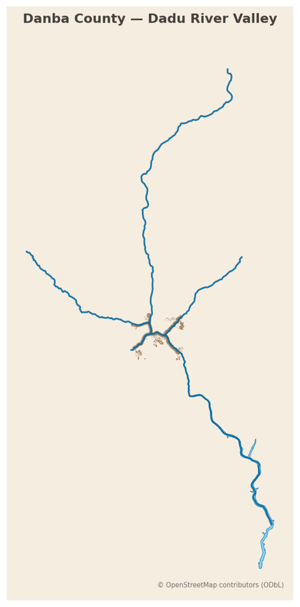

```python
# Pre-generated by generate_danba_map.py — no network call at render time
import matplotlib.pyplot as plt
import matplotlib.image as mpimg

img = mpimg.imread("_export_images/danba-osmnx.png")
fig, ax = plt.subplots(figsize=(9, 9))
ax.imshow(img)
ax.set_axis_off()
plt.tight_layout()
plt.show()
```

## Architecture: Building Without Mortar in Earthquake Country

### Cross-Sectional Geometry

The most remarkable feature of these towers is the diversity of plan geometries, particularly the star-shaped forms found in greatest concentration around Danba County. The following table summarizes documented cross-section types:

Table 1: Plan geometries of documented tower cross-sections.

| Plan Type | Sides/Points | Distribution | Structural Notes |
| --- | --- | --- | --- |
| Square | 4 | Ubiquitous, esp. Qiang | Simplest to build; most common form |
| Hexagonal | 6 | Danba, Maerkang | Greater lateral stability than square |
| Octagonal | 8 | Danba | Transitional between hex and star forms |
| Star (5-pointed) | 5 | Rare; Danba | Interlocking angles resist shear |
| Star (6-pointed) | 6 | Danba, Jinchuan | Resembles a Star of David in plan |
| Star (8-pointed) | 8 | Danba | Complex geometry; high-status buildings |
| Star (12-pointed) | 12 | Very rare; Danba | Among the most geometrically complex |
| Star (13-pointed) | 13 | Extremely rare | Only a handful documented; enigmatic |

```python
plan_data = pd.DataFrame([
    {"Plan Type": "Square", "Estimated %": 55, "tradition": "Qiang + Gyalrong"},
    {"Plan Type": "Hexagonal", "Estimated %": 18, "tradition": "Gyalrong"},
    {"Plan Type": "Octagonal", "Estimated %": 10, "tradition": "Gyalrong"},
    {"Plan Type": "Star (5–6 pt)", "Estimated %": 9, "tradition": "Gyalrong"},
    {"Plan Type": "Star (8–13 pt)", "Estimated %": 8, "tradition": "Gyalrong (elite)"},
])

import plotly.express as px

fig = px.bar(
    plan_data,
    x="Plan Type",
    y="Estimated %",
    color="tradition",
    color_discrete_map={
        "Qiang + Gyalrong": "#78716c",
        "Gyalrong": "#a16207",
        "Gyalrong (elite)": "#7c3d12",
    },
    labels={"Estimated %": "Estimated Share (%)", "tradition": "Tradition"},
    title="Approximate Distribution of Tower Plan Types",
)
fig.update_layout(
    height=340,
    width=680,
    plot_bgcolor="white",
    paper_bgcolor="#faf8f4",
    margin=dict(l=50, r=30, t=50, b=50),
    showlegend=True,
    legend_title_text="Tradition",
)
fig.update_traces(marker_line_width=0.5, marker_line_color="white")
fig.show()
```

[interactive chart not shown]

Estimated distribution of tower plan types. Star-plan towers are concentrated in Danba County and are associated with high-status Gyalrong Tibetan builders.

### Materials and Dimensions

The towers are **dry-stone masonry**: flat, roughly dressed stone slabs stacked without mortar or cement, relying on friction, gravity, and precise fitting for stability. Wall thickness typically ranges from 0.8 m at the base to 0.3 m near the summit, a *battered profile* that lowers the center of gravity and increases resistance to lateral forces (Li and Chen 2009; Wang 2007).

~60 m

Maximum recorded tower height (Danba / Maerkang)

Heights range from 10–40 m for typical examples, with exceptional towers in Danba and Maerkang reaching 50–60 m. For context, a 60-meter stone tower built without mortar in a seismic zone rivals the engineering achievement of a Romanesque cathedral bell tower.

**Star-plan towers and seismic resilience**: Each re-entrant angle in a star plan acts as a buttress, distributing seismic forces across multiple axes rather than concentrating them along four flat walls. The 2008 Wenchuan earthquake (M<sub>s</sub> 8.0) destroyed many square-plan structures but left star-plan towers largely intact (Sun and Zhang 2009).

## Chronology and Purpose

### When Were They Built?

Dating the towers is one of the central unresolved problems in this field. The earliest plausible textual references appear in **Tang Dynasty** (618–907 CE) military records describing fortified stone structures associated with Qiang and Tibetan border peoples. The **Qing Dynasty** (1644–1912) archives are far more detailed, particularly surrounding the **Jinchuan campaigns** (大小金川之役, 1747–1776), in which imperial armies besieged tower-fortified Gyalrong communities. Radiocarbon dating of timber elements has yielded dates spanning roughly 500–1,500 years before present, consistent with a Tang through Ming construction window (Theobald 2013; Tsomu 2015).

A provisional developmental sequence:

1. **Earliest phase** (~6th–9th c.): Square-plan towers, modest heights, integrated with residential compounds.
2. **Middle phase** (~10th–14th c.): Polygonal plans emerge; heights increase; towers become freestanding.
3. **Late phase** (~15th–18th c.): Star-plan towers proliferate; maximum heights reached; towers serve increasingly symbolic and prestige functions.

### Why Build Them?

The towers almost certainly served **multiple, overlapping functions** that shifted over time:

- **Military / defensive**: Elevated observation, refuge during raids, platforms for dropping stones. Confirmed by Qing military records (Theobald 2013).
- **Prestige and social status**: Oral tradition holds that wealthier Gyalrong families built taller, more geometrically complex towers, analogous to the competitive tower-building of San Gimignano in Tuscany or the tower houses of Svaneti in Georgia (Darragon 2003).
- **Storage and economic security**: Evidence of grain storage on upper floors; secure elevated storage was rational in a landscape where arable land was scarce and raiding endemic.
- **Trade route infrastructure**: Distribution along the Tea-Horse Road suggests possible use as waypoints, toll stations, or signal relay points (Yang 2004; Freeman and Ahmed 2015).
- **Ritual and cosmological**: Some researchers and local informants associate towers with spiritual functions: orientation toward sacred peaks, solstice alignment. Difficult to verify systematically but consistent with deep integration of architecture and cosmology in Tibetan and Qiang traditions (Aldenderfer and Zhang 2004).

## Conservation and Comparative Context

### A Heritage at Risk

~250

Towers surviving in recognizable form (down from several thousand)

The **World Monuments Fund** added the Sichuan towers to its Watch List in **2006**, citing “the fragility of these structures and the rapid pace of change in the region.” Threats are multiple and compounding (World Monuments Fund 2006):

- **Seismic damage**: The 2008 Wenchuan earthquake (epicenter ~150 km east of Danba) caused significant damage across the region. The area sits atop the Longmenshan fault system.
- **Water infiltration**: Without mortar, freeze-thaw cycling progressively dislodges stones. Many towers show characteristic bulging or partial collapse.
- **Abandonment**: As younger generations migrate to cities, the villages that maintained towers lose the labor and cultural knowledge necessary for upkeep.
- **Tourism development**: Danba’s designation as a scenic area has brought revenue but also insensitive infrastructure construction near tower sites.

As of the most recent available information, the towers have **not** received UNESCO World Heritage designation, though Chinese authorities have explored nomination.

### Global Comparators

```python
comp = pd.DataFrame([
    {
        "Tradition": "Sichuan diaolou",
        "Location": "W. Sichuan / E. Tibet",
        "Period": "~6th–18th c.",
        "Material": "Dry stone",
        "Max Height": "~60 m",
        "Plan Forms": "Square to 13-star",
    },
    {
        "Tradition": "Svaneti towers",
        "Location": "Georgia (Caucasus)",
        "Period": "9th–13th c.",
        "Material": "Stone/mortar",
        "Max Height": "~25 m",
        "Plan Forms": "Square",
    },
    {
        "Tradition": "San Gimignano",
        "Location": "Tuscany, Italy",
        "Period": "12th–14th c.",
        "Material": "Stone/mortar",
        "Max Height": "~54 m",
        "Plan Forms": "Square",
    },
    {
        "Tradition": "Kaiping diaolou",
        "Location": "Guangdong, China",
        "Period": "19th–20th c.",
        "Material": "Brick/concrete",
        "Max Height": "~30 m",
        "Plan Forms": "Square/rectangular",
    },
    {
        "Tradition": "Tower houses of Shibam",
        "Location": "Yemen",
        "Period": "16th c.+",
        "Material": "Mud brick",
        "Max Height": "~30 m",
        "Plan Forms": "Square",
    },
    {
        "Tradition": "Nuraghi",
        "Location": "Sardinia",
        "Period": "~1900–730 BCE",
        "Material": "Dry stone",
        "Max Height": "~20 m",
        "Plan Forms": "Circular",
    },
])

comp.style\
    .set_properties(**{"font-size": "0.87em"})\
    .set_table_styles([
        {"selector": "th", "props": [
            ("background-color", "#7c3d12"),
            ("color", "#faf8f4"),
            ("font-size", "0.84em"),
            ("padding", "6px 10px"),
        ]},
        {"selector": "td", "props": [("padding", "5px 10px")]},
        {"selector": "tr:nth-child(odd)", "props": [("background-color", "#fefce8")]},
        {"selector": "tr:first-child td", "props": [
            ("font-weight", "600"),
            ("color", "#7c3d12"),
        ]},
    ])\
    .hide(axis="index")
```

Comparative tower-building traditions worldwide. The Sichuan diaolou are globally unique in combining dry-stone construction, star-plan geometry, and heights exceeding 50 m in a seismically active zone.

| Tradition | Location | Period | Material | Max Height | Plan Forms |
| --- | --- | --- | --- | --- | --- |
| Sichuan diaolou | W. Sichuan / E. Tibet | ~6th–18th c. | Dry stone | ~60 m | Square to 13-star |
| Svaneti towers | Georgia (Caucasus) | 9th–13th c. | Stone/mortar | ~25 m | Square |
| San Gimignano | Tuscany, Italy | 12th–14th c. | Stone/mortar | ~54 m | Square |
| Kaiping diaolou | Guangdong, China | 19th–20th c. | Brick/concrete | ~30 m | Square/rectangular |
| Tower houses of Shibam | Yemen | 16th c.+ | Mud brick | ~30 m | Square |
| Nuraghi | Sardinia | ~1900–730 BCE | Dry stone | ~20 m | Circular |

The Sichuan towers exceed all comparators in geometric complexity. No other tradition produced star plans, and they match or exceed all comparators in height while using the most structurally challenging technique (dry stone, no mortar, in a seismic zone). This combination is, as far as current evidence indicates, **globally unique**.

## Data Sources and Technical Details

### Bibliography

Aldenderfer, Mark, and Yinong Zhang. 2004. “The Prehistory of the Tibetan Plateau to the Seventh Century A.D.: Perspectives and Research from China and the West Since 1950.” *Journal of World Prehistory* 18 (1): 1–55.

Darragon, Frédérique. 2003. “The Secret Towers of the Himalayas.”

Freeman, Michael, and Selena Ahmed. 2015. *Tea Horse Road: China’s Ancient Trade Road to Tibet*. River Books.

Kirby, Eric, Kelin X. Whipple, B. Clark Burchfiel, Wenqing Tang, Glenn Berger, Zhiming Sun, and Zhiliang Chen. 2003. “Distribution of Active Rock Uplift Along the Eastern Margin of the Tibetan Plateau.” *Geology* 31 (10): 861–64.

Li, Xiaobo, and Wei Chen. 2009. “Architectural Heritage of Stone Towers in Danba County, Western Sichuan.” *Architectural Journal (建筑学报)* 2009 (6): 78–83.

Liu, Jian et al. 2011. “Post-Earthquake Cultural Heritage Assessment in Yushu, Qinghai Province.” *China Cultural Heritage (中国文化遗产)* 2011 (2): 44–51.

Sun, Baitao, and Guixin Zhang. 2009. “Damage to Historical Stone Towers in Western Sichuan During the 2008 Wenchuan Earthquake.” *Journal of Earthquake Engineering and Engineering Vibration (地震工程与工程振动)* 29 (3): 145–52.

Theobald, Ulrich. 2013. *War Finance and Logistics in Late Imperial China: A Study of the Second Jinchuan Campaign (1771–1776)*. Leiden: Brill.

Tsomu, Yudru. 2015. *The Rise of Gönpo Namgyel in Kham: The Blind Warrior of Nyarong*. Lexington Books.

Wang, Mingke. 2007. “The Qiang and Their Tower-Building Tradition: Ethnohistorical Perspectives.” *Journal of the Royal Asiatic Society* 17 (2): 151–68.

World Monuments Fund. 2006. “2006 World Monuments Watch: 100 Most Endangered Sites.” https://www.wmf.org/watch.

Yang, Bin. 2004. “Horses, Silver, and Cowries: Yunnan in Global Perspective.” *Journal of World History* 15 (3): 281–322.

Yin, An, and T. Mark Harrison. 2000. “Geologic Evolution of the Himalayan-Tibetan Orogen.” *Annual Review of Earth and Planetary Sciences* 28: 211–80.

### Technical Notes

```python
import sys, platform, folium, pandas as pd, matplotlib

print("Environment")
print(f"  Python:     {sys.version.split()[0]}")
print(f"  Platform:   {platform.system()} {platform.release()}")
print(f"  pandas:     {pd.__version__}")
print(f"  folium:     {folium.__version__}")
print(f"  matplotlib: {matplotlib.__version__}")
import osmnx as ox
print(f"  osmnx:      {ox.__version__}")

print("\nData Sources")
print("  StoneTowerSites.json   — 7 curated site clusters (this project)")
print("  stonetowerstibet.md    — primary scholarly source document")
print("  Esri WorldShadedRelief — terrain basemap (ArcGIS REST)")
print("  CARTO Voyager Labels   — label overlay (optional)")
print("  OpenStreetMap          — prettymaps base data")
print("  \u00a9 OpenStreetMap contributors (ODbL)")

print("\nSite Summary")
print(f"  Total sites: {len(sites)}")
for grp, cnt in sites_df.groupby("ethnic_group").size().items():
    print(f"  {grp}: {cnt} clusters")
```

```
Environment
  Python:     3.11.9
  Platform:   Windows 10
  pandas:     2.2.2
  folium:     0.20.0
  matplotlib: 3.10.8
  osmnx:      1.9.4

Data Sources
  StoneTowerSites.json   — 7 curated site clusters (this project)
  stonetowerstibet.md    — primary scholarly source document
  Esri WorldShadedRelief — terrain basemap (ArcGIS REST)
  CARTO Voyager Labels   — label overlay (optional)
  OpenStreetMap          — prettymaps base data
  © OpenStreetMap contributors (ODbL)

Site Summary
  Total sites: 7
  Gyalrong Tibetan: 3 clusters
  Qiang: 2 clusters
  Tibetan (mixed/unknown): 2 clusters
```

Built with Quarto • Template: Quarto GIS Research Starter